# Bayesien_hw3

Ching-Tsung_Deron_Tsai

2022/10/31

```r
library(tidyverse)
library(MCMCpack)
library(MASS)
library(spam)
library(ggpubr)
# functions for updating parameters in multivariate normal model:
sample.theta <- function(ybar,mu0,Lambda0,n,Sigma){
    iLambda0 <- solve(Lambda0)  # prior precision matrix
    iSigma <- solve(Sigma)      # data precision matrix
    post.prec <- n*iSigma + iLambda0  # posterior precision matrix
    post.var <- solve(post.prec)  # posterior variance matrix
    post.mean <- post.var%*%(iLambda0%*%mu0 + n*iSigma%*%ybar) # posterior mean
    new.theta <- mvrnorm(1,post.mean,post.var)
    return(new.theta)
}

sample.Sigma <- function(y,theta,n,nu0,Phi0){
    nu.n <- n+nu0    # posterior degrees of freedom
    rss <- (t(y)-theta)%*%t(t(y)-theta)  # residual sum of squares
    Phi.n <- Phi0+rss
    new.iSigma <- rwish(nu.n,solve(Phi.n))
    new.Sigma <- solve(new.iSigma)
    return(new.Sigma)
}
```

### 7.3

**a**

```r
blue <- read.table("../HW_Q/bluecrab.dat")
orange <- read.table("../HW_Q/orangecrab.dat")
lst <- list(blue,orange)
# predifined values:
B=1e4
nu0 = 4
# joint posterior of the two data:
posterior <- lapply(1:2, function(i){
  # prior parameters & observation info:
  n = nrow(lst[[i]])
  mu0 = colMeans(lst[[i]])
  s0 = cov(lst[[i]])
  # to save posterior:
  theta.MC <- matrix(0,B,2)
  Sigma.MC <- array(0,dim=c(2,2,B))
  # gibbs sampling:
  set.seed(i)
  for(j in 1:B){
    if(j==1){
        theta.MC[j,] <- mu0
        Sigma.MC[,,j] <- s0
    }
    if(j>1){
        theta.MC[j,] <- sample.theta(mu0,mu0,s0,n,Sigma.MC[,,(j-1)])
        Sigma.MC[,,j] <- sample.Sigma(lst[[i]],theta.MC[j,],n,nu0,s0)
    }
  }
  return(list(mean=theta.MC, variance=Sigma.MC))
})
names(posterior) <- c("blue","orange")
```

**b**

Generally, both theta1 & theta 2 are larger in orange crab comparing to blue crab. According to 95% confidence interval of the Gibbs sampling, we can say theta 2 is larger in orange crab, while theta 1 may not have a significant difference.

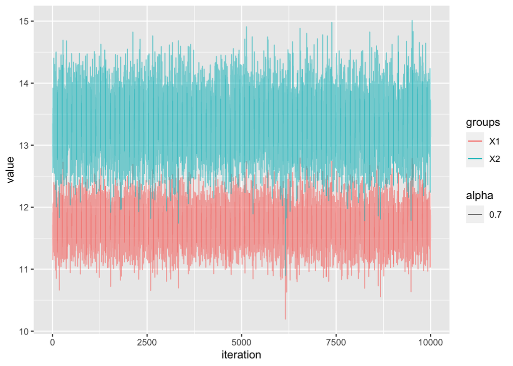

```r
blue.theta <- posterior$blue$mean
orange.theta <- posterior$orange$mean
data.frame(blue.theta,iteration=1:B) %>%
  pivot_longer(cols=c("X1","X2"), names_to = "groups") %>%
  ggplot() + geom_line(aes(x=iteration, y=value, col=groups,alpha=0.7))
```

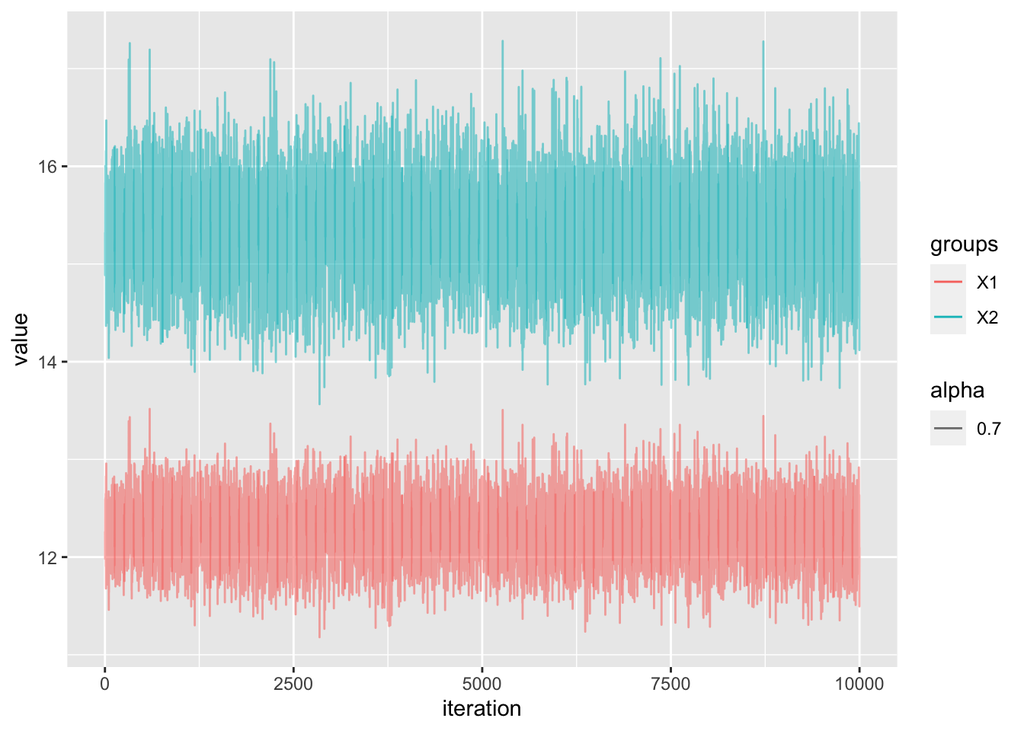

```r
blue.theta <- blue.theta[-c(1:1000),]
data.frame(orange.theta,iteration=1:B) %>%
  pivot_longer(cols=c("X1","X2"), names_to = "groups") %>%
  ggplot() + geom_line(aes(x=iteration, y=value, col=groups,alpha=0.7))
```

```r
orange.theta <- orange.theta[-c(1:1000),]
ci <- apply(cbind(blue.theta,orange.theta), 2, quantile,c(0.025,0.975))
colnames(ci) <- c("theta_1_blue","theta_2_blue","theta_1_orange","theta_2_orange")
ci
```

```
##       theta_1_blue theta_2_blue theta_1_orange theta_2_orange
## 2.5%      11.12600     12.45852       11.66032       14.35664
## 97.5%     12.30141     14.22886       12.87612       16.31474
```

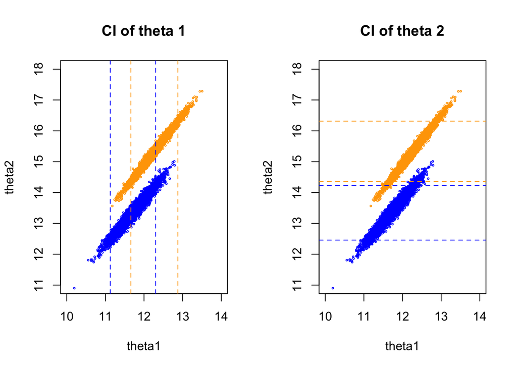

```r
par(mfrow=c(1,2))
plot(blue.theta[,1],blue.theta[,2], cex=0.3,main="CI of theta 1",
     xlab = "theta1",ylab = "theta2",xlim = c(10,14),ylim=c(11,18), col="blue")
points(orange.theta[,1],orange.theta[,2], cex=0.3,col="orange")
abline(v = ci[,1], col = "blue",lty=2)
abline(v = ci[,3], col = "orange",lty=2)
plot(blue.theta[,1],blue.theta[,2], cex=0.3,main="CI of theta 2",
     xlab = "theta1",ylab = "theta2",xlim = c(10,14),ylim=c(11,18), col="blue")
points(orange.theta[,1],orange.theta[,2], cex=0.3,col="orange")
abline(h = ci[,2], col = "blue",lty=2)
abline(h = ci[,4], col = "orange",lty=2)
```

```r
par(mfrow=c(1,1))
```

**c**

We can get the correlation from the covariance matrix via $CORR(X,Y)=\frac{COV(X,Y)}{SD(x)*SD(y)}$

$\Pr(\rho_{\text{blue}}<\rho_{\text{orange}}|y_{\text{blue}},y_{\text{orange}})=0.9873$ in the posterior distribution I sampled. The result showed that the correlation is generally higher in group orange.

```r
corr <- function(mx) mx[1,2] / (sqrt(mx[1,1])*sqrt(mx[2,2]))  # correlation
posterior_corr <- lapply(posterior, function(dat){
  apply(dat[["variance"]], 3, corr)
})
mean(posterior_corr$blue < posterior_corr$orange)
```

```
## [1] 0.9873
```

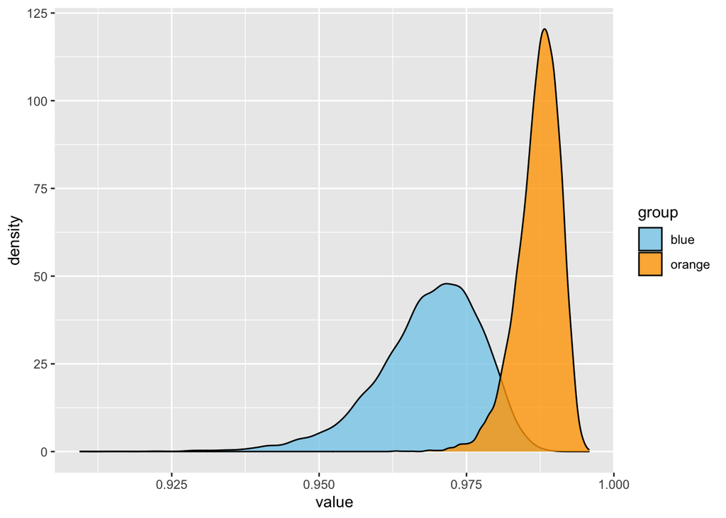

```r
data.frame(posterior_corr) %>%
  pivot_longer(cols=c("blue","orange"), names_to = "group") %>%
  ggplot(aes(x=value,fill=group)) +
  geom_density(alpha=0.8) +
  scale_fill_manual(values = c("blue" = "skyblue", "orange"="orange"))
```

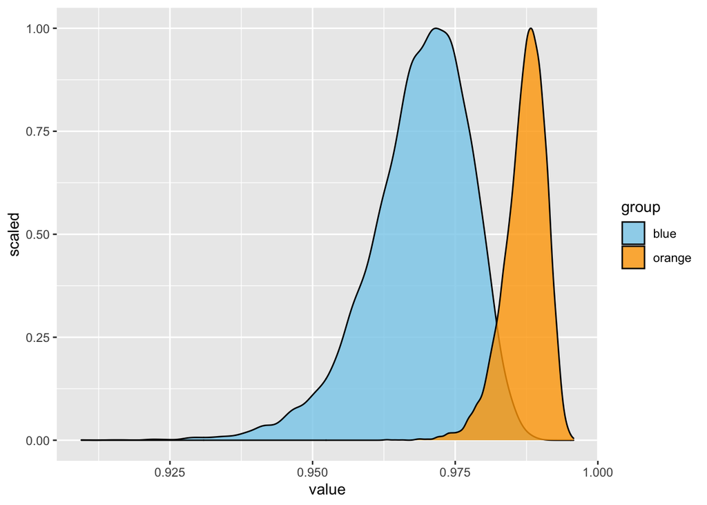

```r
data.frame(posterior_corr) %>%
  pivot_longer(cols=c("blue","orange"), names_to = "group") %>%
  ggplot(aes(x=value,fill=group, ..scaled..)) +   # scaled to a probability density
  geom_density(alpha=0.8) +
  scale_fill_manual(values = c("blue" = "skyblue", "orange"="orange"))
```

### 7.4

**a**

```r
ages <- read.table("../HW_Q/agehw.dat", header = T)
summary(ages) # summary stats
```

```
##       ageh            agew
##  Min.   :22.00   Min.   :17.00
##  1st Qu.:34.00   1st Qu.:31.00
##  Median :41.50   Median :39.00
##  Mean   :44.42   Mean   :40.89
##  3rd Qu.:52.00   3rd Qu.:47.25
##  Max.   :79.00   Max.   :72.00
```

```r
# sample mean, cov, and number of observation:
ybar <- colMeans(ages)
n = nrow(ages)
```

We can get $\bar y=$ 44.42, 40.89 and n=100 from the data set.

According to the 2021 Knot Real Wedding Study, average wedding age is 33 for women and 35 for men. While the average life expectancy in USA is 80 for women and 75 for men. I would give a very rough estimation for the prior mean as $\frac{80+33}{2}=56.5$ for women and $\frac{35+75}{2}=55$ for men.

I don’t have any specific guess for the prior variance, therefore I would like to set a large range as a weak prior. Let’s say $\Lambda_0=20^2=400$. Since husband and wife often have similar ages. I would set a relative high correlation 0.7. I would set a $\nu_0=4$ that is slightly higher than p=2, and $s_0=\Lambda_0$.

Now we have all the needed prior information for setting a semi-conjugate prior distribution.

$$\begin{align}
0.7 = COV/(20*20) \to COV = 280 \\
\theta =(\theta_h,\theta_w)^T \sim N(\mu_0,\Lambda_0) = N((55,56.5)^T,
\begin{bmatrix}
400 & 280\\
280 & 400
\end{bmatrix}) \\
\Sigma \sim InverseWishart(4,\begin{bmatrix}
400 & 280\\
280 & 400
\end{bmatrix})
\end{align}$$

**b**

Using my beginning settings. The structure is a little bit different to the prior. After I made the variance smaller, several data set did have a highly correlated structure, and the mean is around the prior. If we compare the posterior(red dot) with observed data(blue dot), posterior also did contains the range of observations.

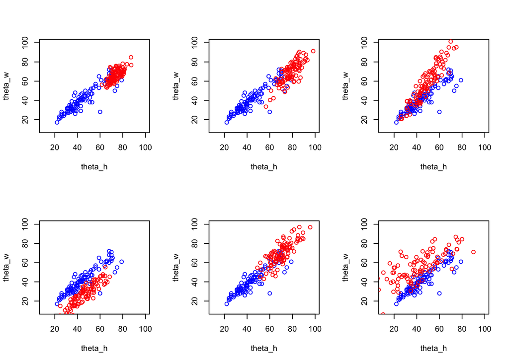

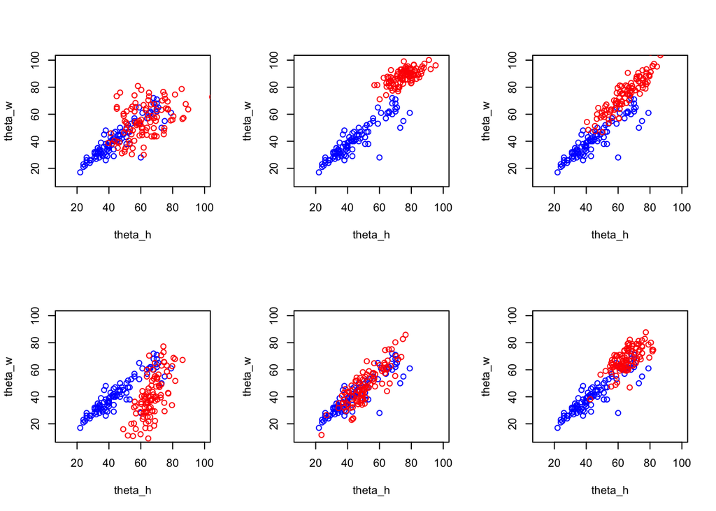

```r
ybar <- colMeans(ages)
n = nrow(ages)
mu0 = c(55,56.5)
#mu0 = ybar
# s0 = lambda0 = matrix(c(400,280,280,400),nrow=2)
s0 = lambda0 = matrix(c(225,157.5,157.5,225),nrow=2)
# s0 = lambda0 = matrix(c(225,112.5,112.5,225),nrow=2)
nu0 = 4
B = 100
nsets = 12   # number of repeat data set
set.seed(0)
posterior <- lapply(1:nsets, function(i){
  theta = rmvnorm(1, mu0, lambda0)
  sigma = solve(rWishart(1, nu0, solve(s0))[, , 1])
  Y.sim = rmvnorm(n, theta, sigma)
})
par(mfrow=c(2,3))
for (i in 1:nsets){
  val <- posterior[[i]]
  plot(ages[,1],ages[,2], xlim = c(10,100), ylim = c(10,100),
     xlab = "theta_h",ylab = "theta_w", col="blue")
  points(val[,1],val[,2],col="red")
}
```

**c**

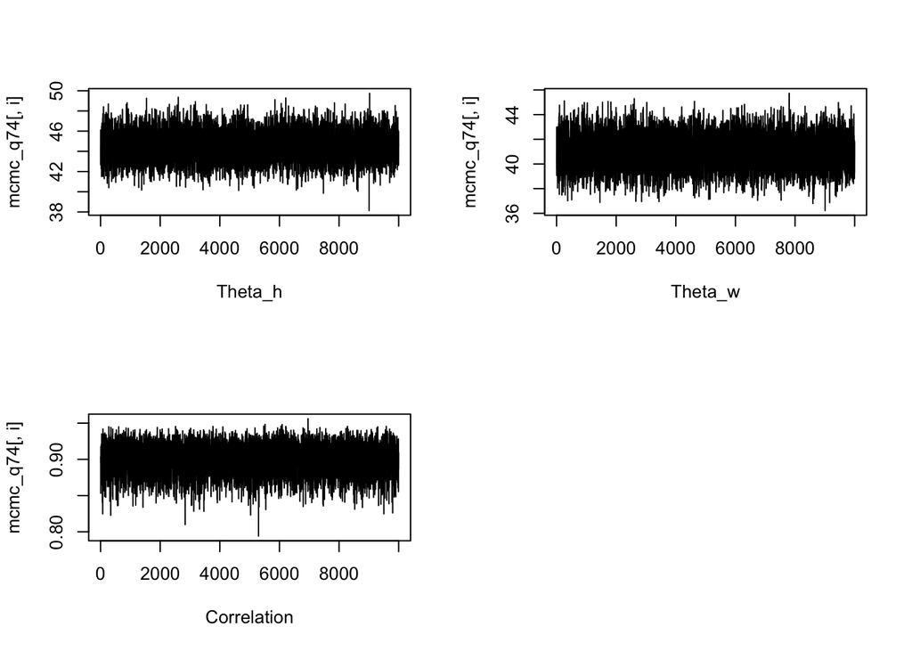

```r
B <- 1e4
theta.MC <- matrix(0,B,2)
Sigma.MC <- array(0,dim=c(2,2,B))
s2 = cov(ages)
set.seed(0)
for (i in 1:B){
  if(i==1){
        Sigma.MC[,,i] <- s2
          theta.MC[i,] <- ybar
    }
  if (i>1){
        theta.MC[i,] <- sample.theta(ybar,mu0,lambda0,n,Sigma.MC[,,(i-1)])
          Sigma.MC[,,i] <- sample.Sigma(ages,theta.MC[i,],n,nu0,s0)
    }
}
mcmc_q74 <- cbind(theta.MC,
      sapply(1:B, function(i) corr(Sigma.MC[,,i])))
colnames(mcmc_q74) <- c("Theta_h","Theta_w", "Correlation")
# trace plot:
par(mfrow=c(2,2))
for (i in 1:3){
  plot(mcmc_q74[,i], type="l", xlab = colnames(mcmc_q74)[i])
}
par(mfrow=c(1,1))
```

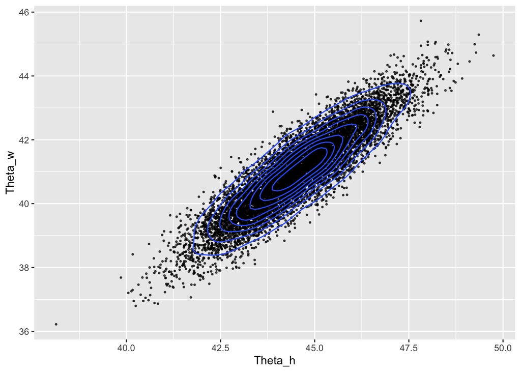

```r
mcmc_q74 <- mcmc_q74[-c(1:1000),]
# visualization:
ggplot(data.frame(mcmc_q74), aes(x=Theta_h, y=Theta_w)) +
  geom_point(size=0.5, alpha=0.7)+ geom_density2d()
```

```r
# 95% CI:
apply(mcmc_q74,2,quantile,c(0.025,0.975))
```

```
##        Theta_h  Theta_w Correlation
## 2.5%  41.91222 38.55084   0.8590268
## 97.5% 47.23054 43.50682   0.9324882
```

**d and e**

According to the confidence interval, the prior I defined has a smaller range in correlations. But the range of theta didn’t have much difference. I will say the help of the prior I defined is limited.

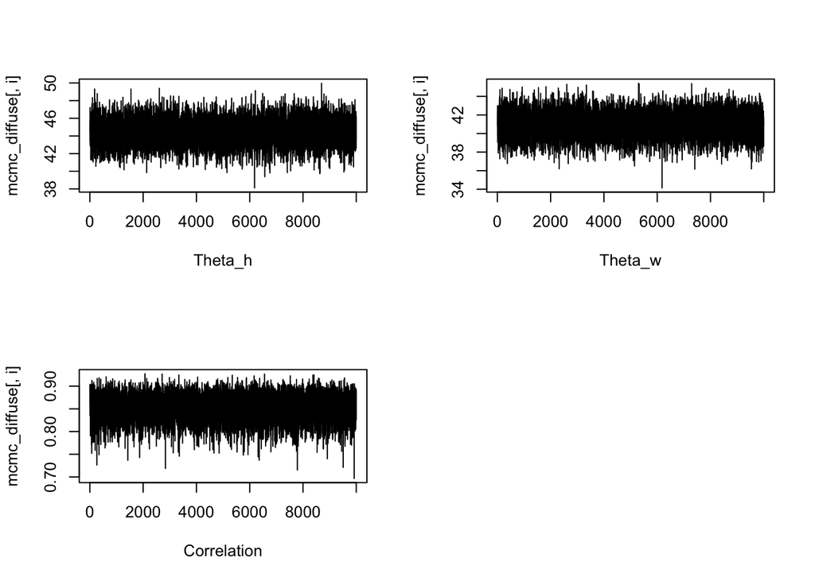

```r
# diffuse prior:
mu0 = c(0,0); lambda0 = 1e5*diag(2) ; s0 = 1000*diag(2) ; nu0=3
B <- 1e4
theta.MC <- matrix(0,B,2)
Sigma.MC <- array(0,dim=c(2,2,B))
s2 = cov(ages)
set.seed(1)
for (i in 1:B){
  if(i==1){
        Sigma.MC[,,i] <- s2
          theta.MC[i,] <- ybar
    }
  if (i>1){
        theta.MC[i,] <- sample.theta(ybar,mu0,lambda0,n,Sigma.MC[,,(i-1)])
          Sigma.MC[,,i] <- sample.Sigma(ages,theta.MC[i,],n,nu0,s0)
    }
}
mcmc_diffuse <- cbind(theta.MC,
      sapply(1:B, function(i) corr(Sigma.MC[,,i])))
colnames(mcmc_diffuse) <- c("Theta_h","Theta_w", "Correlation")
# trace plot:
par(mfrow=c(2,2))
for (i in 1:3){
  plot(mcmc_diffuse[,i], type="l", xlab = colnames(mcmc_diffuse)[i])
}
par(mfrow=c(1,1))
```

```r
mcmc_diffuse <- mcmc_diffuse[-c(1:1000),]
# Diffuse prior:
apply(mcmc_diffuse,2,quantile,c(0.025,0.975))
```

```
##        Theta_h  Theta_w Correlation
## 2.5%  41.75203 38.27166   0.7935270
## 97.5% 47.20240 43.46202   0.8997456
```

```r
# Personal defined prior:
apply(mcmc_q74,2,quantile,c(0.025,0.975))
```

```
##        Theta_h  Theta_w Correlation
## 2.5%  41.91222 38.55084   0.8590268
## 97.5% 47.23054 43.50682   0.9324882
```

### 7.6

**a**

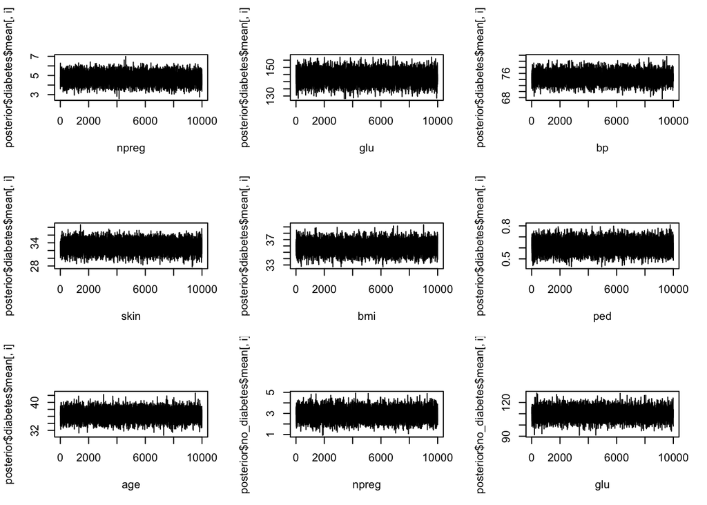

```r
raw <- read.table("../HW_Q/azdiabetes.dat", header = T)
diabetes <- raw[raw$diabetes=="Yes",-8]
no_diabetes <- raw[raw$diabetes=="No",-8]
# diabetes:
B <- 1e4
p <- ncol(diabetes)
set.seed(3)
posterior <- lapply(list(diabetes=diabetes, no_diabetes=no_diabetes), function(df){
  theta.MC <- matrix(0,B,p)
  Sigma.MC <- array(0,dim=c(p,p,B))
  mu0 <- ybar <- colMeans(df)
  s0 <- lambda0 <- s2 <- cov(df)
  nu0 <- 2+p
  for (i in 1:B){
    if(i==1){
        Sigma.MC[,,i] <- s2
          theta.MC[i,] <- ybar
      }
    if (i>1){
        theta.MC[i,] <- sample.theta(ybar,mu0,lambda0,n,Sigma.MC[,,(i-1)])
          Sigma.MC[,,i] <- sample.Sigma(df,theta.MC[i,],n,nu0,s0)
      }
  }
  return(list(mean=theta.MC, variance=Sigma.MC))
  })
# trace plot:
par(mfrow=c(3,3))
for (i in 1:7){
  plot(posterior$diabetes$mean[,i], type="l", xlab = names(raw)[i])
}
for (i in 1:7){
  plot(posterior$no_diabetes$mean[,i], type="l", xlab = names(raw)[i])
}
```

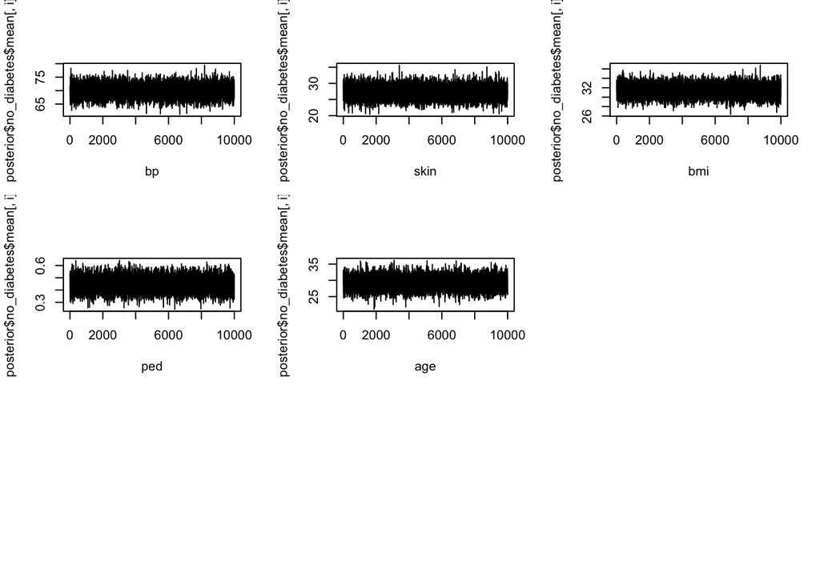

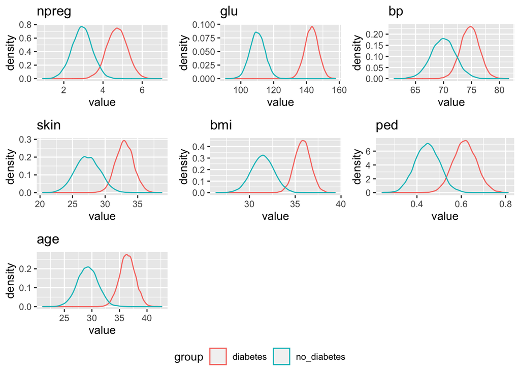

```r
par(mfrow=c(1,1))
posterior$diabetes$mean <- posterior$diabetes$mean[-c(1:1000),]
posterior$no_diabetes$mean <- posterior$no_diabetes$mean[-c(1:1000),]

pt <- lapply(1:p, function(col){
  data.frame(diabetes=posterior[["diabetes"]]$mean[,col],
             no_diabetes=posterior[["no_diabetes"]]$mean[,col]) %>%
    pivot_longer(cols=c("diabetes","no_diabetes"), names_to = "group") %>%
    ggplot() +
    geom_density(aes(x=value, col=group)) +
    ggtitle(names(raw)[col])
})
ggarrange(plotlist=pt, common.legend = TRUE, legend="bottom")
```

```r
# P(diabetes>not diabetes|Y):
prob <- colMeans(posterior[["diabetes"]]$mean > posterior[["no_diabetes"]]$mean)
names(prob) <- names(raw)[-8]
prob
```

```
##     npreg       glu        bp      skin       bmi       ped       age
## 0.9921111 1.0000000 0.9591111 0.9938889 0.9987778 0.9861111 0.9986667
```

According to the visualization and $\Pr(\theta_{d,j}>\theta_{n,j}|Y)=$ 0.9921111, 1, 0.9591111, 0.9938889, 0.9987778, 0.9861111, 0.9986667 for npreg, glu, bp, skin, bmi, ped, age respectively. All variables have greater value in group that has diabetes.

**b**

Overall, people with no diabetes tend to have larger variance and covariance. Some of the features have similar variance/covariance in two groups since some points exist on the line with slope=1.

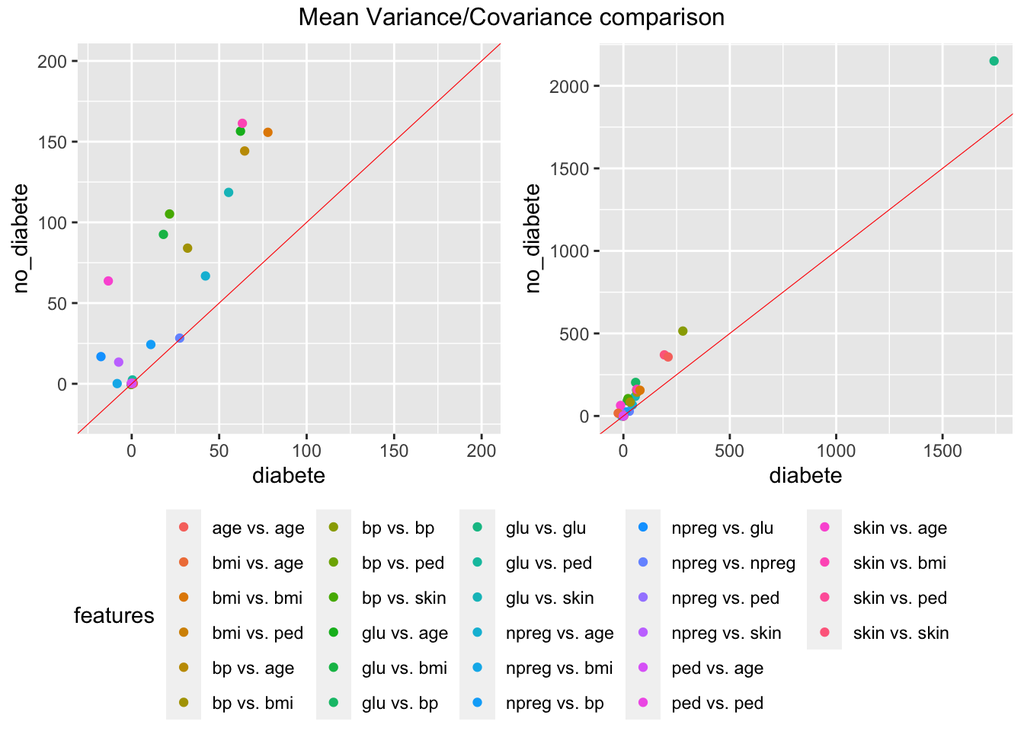

```r
dia_mx <- matrix(0,7,7)
no_diat_mx <- matrix(0,7,7)
for (i in 1:1e4){
  dia_mx <- dia_mx + posterior$diabetes$variance[,,i]
  no_diat_mx <- no_diat_mx + posterior$no_diabetes$variance[,,i]
}
dia_mx <- dia_mx/1e4
no_diat_mx <- no_diat_mx/1e4
mean_cov <- NULL
for (i in 1:7){
  for (j in i:7){
    mean_cov <- rbind(mean_cov,c(diabete=dia_mx[i,j],no_diabete=no_diat_mx[i,j],
      features=paste0(names(raw)[i]," vs. ",names(raw)[j])))
  }
}
p1 <- data.frame(mean_cov) %>%
  mutate_at(vars(diabete, no_diabete), as.numeric) %>%
  ggplot() +
  geom_point(aes(x=diabete, y=no_diabete, col=features)) +
  geom_abline(slope=1, lwd=0.2, col="red") + xlim(-20,200) + ylim(-20,200)
p2 <- data.frame(mean_cov) %>%
  mutate_at(vars(diabete, no_diabete), as.numeric) %>%
  ggplot() +
  geom_point(aes(x=diabete, y=no_diabete, col=features)) +
  geom_abline(slope=1, lwd=0.2, col="red")
p4 <- ggarrange(p1,p2, common.legend = TRUE, legend="bottom")
annotate_figure(p4, top = text_grob("Mean Variance/Covariance comparison"))
```

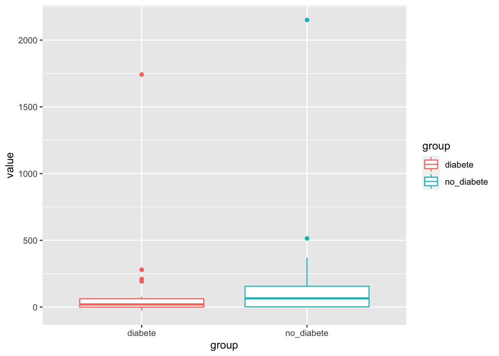

```r
data.frame(mean_cov) %>%
  pivot_longer(cols=c("diabete", "no_diabete"), names_to = "group") %>%
  mutate(value=as.numeric(value)) %>%
  ggplot() +
  geom_boxplot(aes(x=group,y=value,col=group))
```